# **Trabalho Análise Preditiva**

### Testando a presença de outliers

```r
outlier(df$JobSatisfaction)
```

```
## [1] 0
```

- O teste apontou que a categoria zero de JobSatisfaction é outlier e, sendo assim a retiraremos da base de dados a ser modelada.

```r
df<-df[ df$JobSatisfaction != "0", , drop=FALSE]
```

### Novo boxplot e histograma sem outliers em JobSatisfaction

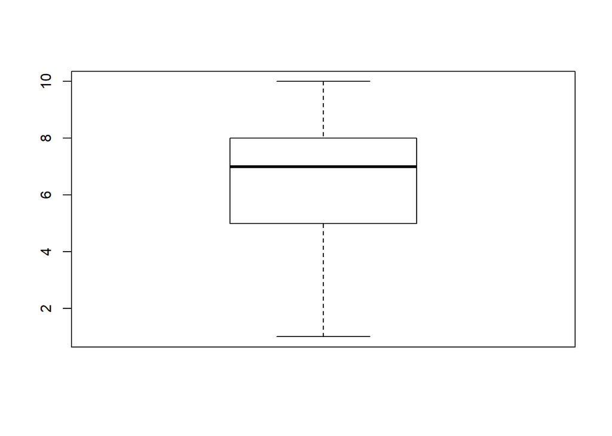

```r
boxplot(df$JobSatisfaction)
```

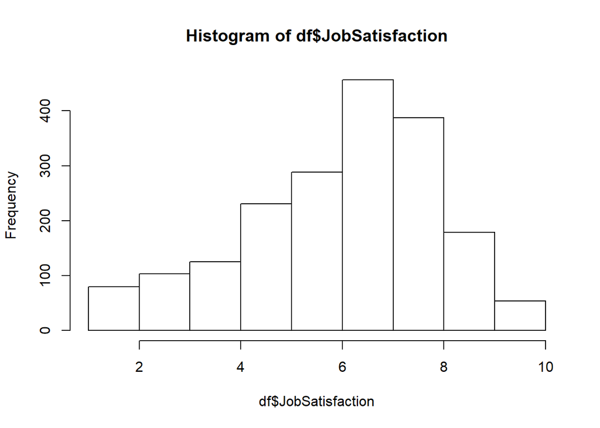

```r
hist(df$JobSatisfaction)
```

## **Classificação Floresta Aleatória**

- Como a base possui muitas variáveis, utilizaremos o Modelo de Classificação Random Forest para nos ajudar na escolha das melhores variáveis preditoras de JobSatisfacion.

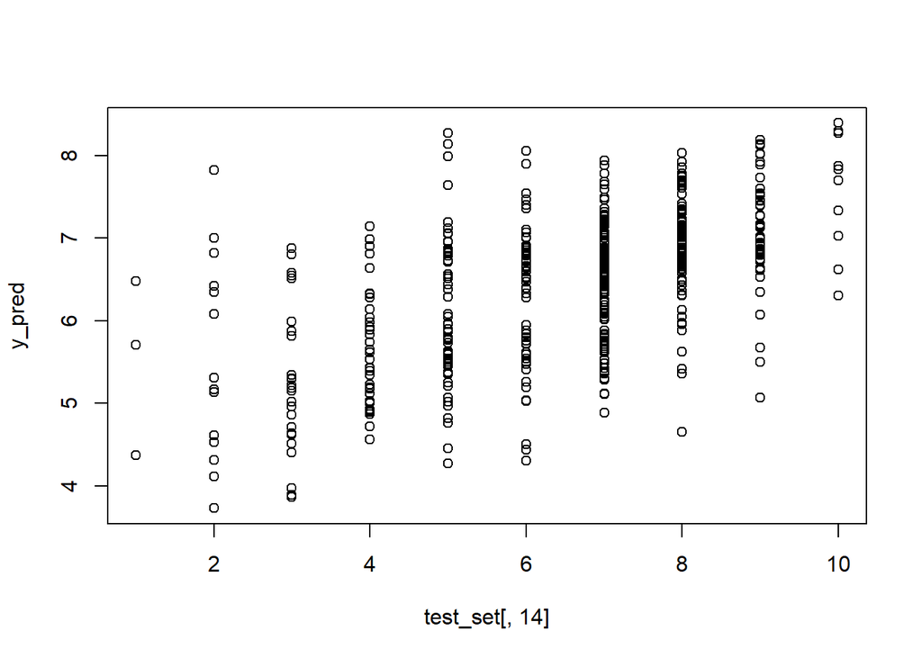

```r
# Dividindo o conjunto de dados no conjunto de treinamento e no conjunto de teste
set.seed(123)
ind <- sample(1:nrow(df), size = .75*nrow(df), replace = F)
training_set = df[ind,]
test_set = df[-ind,]

# Identificando as variáveis com mais de 53 níveis (que a função randomForest não aceita)
ind_col <- NULL
for (i in (1:ncol(training_set))) {
  ifelse(length(levels(training_set[,i]))<54,ind_col[i]<-TRUE,ind_col[i]<-FALSE)
}

# base de treino só com variáveis preditoras
training_set_pred <- training_set[,-14]

# Fazendo a floresta aleatória só com as variáveis preditoras que tenham menos de 53 níveis
set.seed(123)
classifier = randomForest(x = training_set_pred[,which(ind_col[-14]==TRUE)],
                          y = training_set$JobSatisfaction,
                          ntree = 100)

# Previsão dos resultados de teste
y_pred = predict(classifier, newdata = test_set)

# Fazendo a matriz de confusão
cm = table(test_set[,14], y_pred)
cm_dat = data.frame(cm)
plot(test_set[,14], y_pred)
```

## **Escolhendo o número de árvores**

- Ao avaliar o númrero de árvores, identificamos que a partir dos 40 níveis o modelo não tem uma melhora na performance

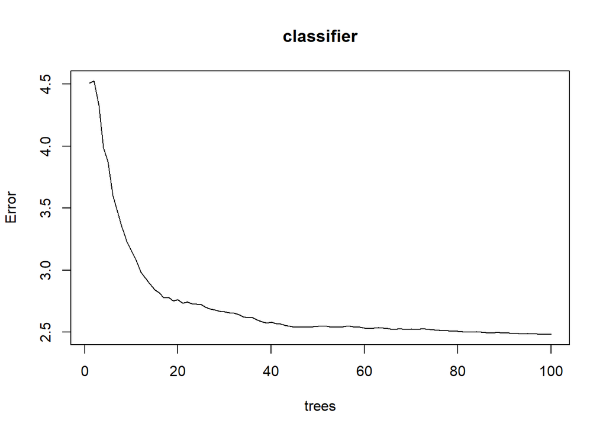

```r
plot(classifier)
```

- Escolhendo as variáveis mais significativas, tendo como critério diminuição média na impureza dos nós (estatística de Gini)

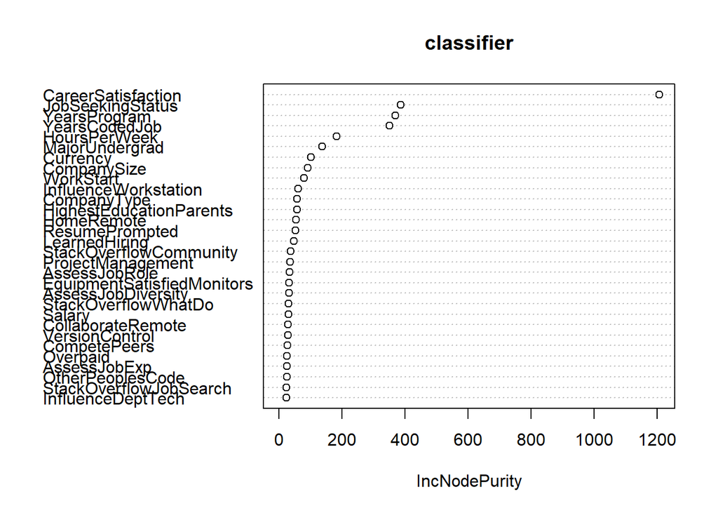

```r
varImpPlot(classifier)
```

```r
#varImp
# Tabela com o valor da estatística de Gini em cada variável
importance_dat = data.frame(importance(classifier))
#View(importance_dat)
```

- A partir das variáveis preditoras pré-selecionadas pelo Modelo de Classificação Random Forest, faremos uma regressão linear:

## **Modelo Linear**

```r
#Selecionadas (a princípio) as variáveis com índice de Gini > 60
mod = lm(JobSatisfaction ~ CareerSatisfaction
         #+ JobSeekingStatus
         + YearsProgram
         + YearsCodedJob + HoursPerWeek + MajorUndergrad
         #+ Currency
         + CompanySize
         #+ WorkStart
         + ResumePrompted + CompanyType + HighestEducationParents
         + InfluenceWorkstation + Overpaid + HomeRemote,
         data=training_set)
```

```r
#print(mod)
#summary(mod)

yhat <- predict(mod, test_set)
mean((yhat-test_set$JobSatisfaction)^2)
```

```
## [1] 2.463262
```

### Job Satisfaction - Base de treino

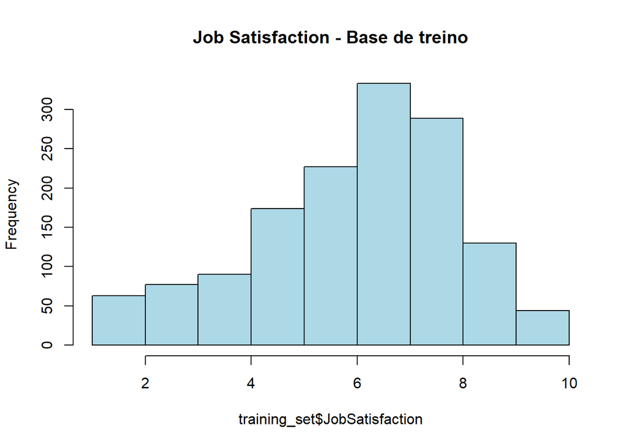

```r
#par(mfrow=c(2,2))
hist(training_set$JobSatisfaction, main= "Job Satisfaction - Base de treino", col="lightblue")
```

### Job Satisfaction - Base de teste

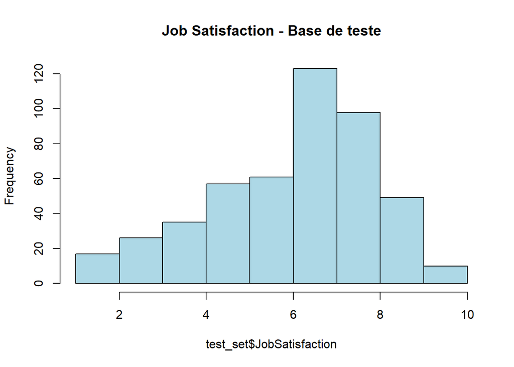

```r
hist(test_set$JobSatisfaction, main= "Job Satisfaction - Base de teste", col="lightblue")
```